# Stat Learning Project

Author

Sofía Karsaclian, Elias Heppner, Andri Rutschmann

## Statistical Learning: Final Project

- Sofía Karsaclian (01/1246546)
- Elias Heppner (01/1244414)
- Andri Rutschmann (01/1246603)

# Data Exploration and Feature Selection

## Exploration

We investigated the data by inspecting summary statistics and plotting histograms of all feature variables. The dataset consists of 569 observations and contains 30 features, consisting of the mean, standard error and worst value of 10 different metrics.

All features are numeric and in essence normally distributed, though many are heavily right-skewed. This is reasonable for the standard error and worst value features as they consist of values close to 0 and thus cannot be left-skewed. It is unclear why many of the mean features are right skewed.

*Figure 1*

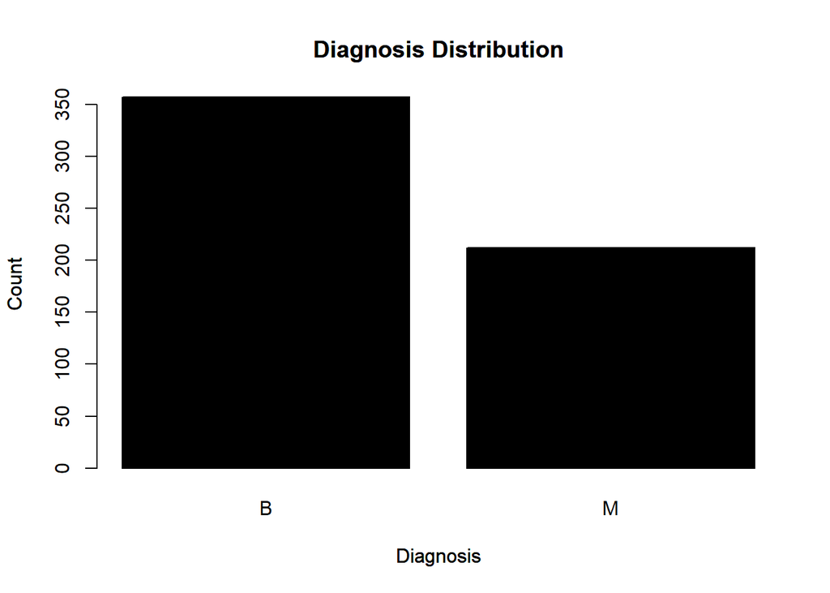

Concerning the target variable, diagnosis, a simple barplot reveals that the dataset is unbalanced. About 37 percent of all observations are malignant, whereas about 63 percent are benign.

## Feature Selection

We investigated both the correlation of all features with the target variable as well as pair-wise correlation between the features.

*Table 1*

| variable | correlation |
| --- | --- |
| texture_mean | 0.4151853 |
| smoothness_mean | 0.3585600 |
| symmetry_mean | 0.3304986 |
| fractal_dimension_mean | -0.0128376 |
| texture_se | -0.0083033 |
| smoothness_se | -0.0670160 |
| compactness_se | 0.2929992 |
| concavity_se | 0.2537298 |
| concave.points_se | 0.4080423 |
| symmetry_se | -0.0065218 |
| fractal_dimension_se | 0.0779724 |
| texture_worst | 0.4569028 |
| smoothness_worst | 0.4214649 |
| symmetry_worst | 0.4162943 |
| fractal_dimension_worst | 0.3238722 |

Inspecting the correlation between the features and the target variable revealed low correlation values for the features presented in Table 1. A simple logistic regression further revealed a statistically insignificant relation between the target variable and the features shown in Table 2.

*Table 2*

| variable | p_value | significant |
| --- | --- | --- |
| fractal_dimension_mean | 0.7594710 | No |
| texture_se | 0.8430081 | No |
| smoothness_se | 0.1125108 | No |
| symmetry_se | 0.8763827 | No |
| fractal_dimension_se | 0.0705555 | No |

A correlation plot of the feature variables reveals high correlations between some of them. Dropping features with a correlation greater than 0.9. would lead to a reduction by 10 features, greatly reducing the dimensionality of the data.

*Figure 2*

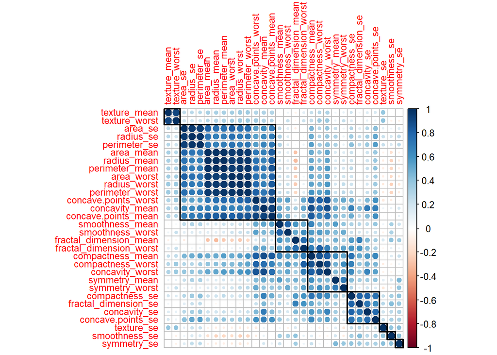

Nevertheless, we decided not to omit any features. Given the models we use, neither a high correlation across features nor an insignificant relation to the target variable merit exclusion.

# Model Introduction And Comparison

We are going to compare two different models for this project: eXtreme Gradient Boosting (XGBoost) and lasso regression. Hence, we do not need to perform normalization and feature selection ourselves.  
XGBoost, being a decision tree based model, does not require normalization and due to our use of the glmnet library normalization is performed automatically when we fit our lasso regression.  
Regarding feature selection we exploit the fact that XGBoost as well as lasso inherently perform feature selection. XGBoost does so due to the fact that the maximum tree depth is limited to a specific $n$ and the algorithm therefore only splits on the $n$ most informative splitting criteria. Lasso uses a penalty to restrict the number of features that influence the model thereby reducing dimensionality.  
Hence, given the small size of the dataset, dropping features yields little in terms of computing speed and omits data that is nevertheless potentially useful for XGBoost and and not detrimental to lasso regression.

Following Emil Hvitfeldt’s and Julia Silge’s [Supervised Machine Learning for Text Analysis in R](https://smltar.com/), we fit both models using the tidymodels R package. After cross-validating different distributions we split our data into 80% training and 20% testing data. This resulted in the best model performances. To optimize hyperparameter settings we used 10-fold cross validation and the recall metric.  
We regarded it as most important to avoid false negatives when dealing with cancer data, leading us to weigh a model’s recall more heavily than its F1-score, precision, or roc-auc measure.

## eXtreme Gradient Boosting (XGBoost)

XGBoost allows for many tunable hyperparameters. The more of these we tune, the more we increase computing time for model fitting. Thus, we started out with a baseline approach. We only tuned the number of decision trees and used the xgboost R package’s default values for the other parameters. We then also tuned the depth of the trees, further increasing an already good performance. Moreover, we tried to optimize performance by tuning all hyperparameters, but after performing 10-fold cross validation on 25,000 models - a time consuming process - we could not observe any additional improvements. It seems that the default values for learning rate, loss reduction, and minimum node weight hit a sweet spot.

Below we see the model performance on the test data.  
Once for the model where we only tuned the number of trees and their respective depth (optimal):

*Table 3*

| .metric | .estimator | .estimate | .config |
| --- | --- | --- | --- |
| f_meas | binary | 0.9655172 | Preprocessor1_Model1 |
| precision | binary | 0.9545455 | Preprocessor1_Model1 |
| recall | binary | 0.9767442 | Preprocessor1_Model1 |
| roc_auc | binary | 0.9903101 | Preprocessor1_Model1 |

And for the model where we tuned all hyperparameters:

*Table 4*

| .metric | .estimator | .estimate | .config |
| --- | --- | --- | --- |
| f_meas | binary | 0.9761905 | Preprocessor1_Model1 |
| precision | binary | 1.0000000 | Preprocessor1_Model1 |
| recall | binary | 0.9534884 | Preprocessor1_Model1 |
| roc_auc | binary | 0.9977390 | Preprocessor1_Model1 |

Of course, extensively tuning all parameters will eventually yield the best model. This takes a lot of resources though, and due to the fact that we already fitted a model on the default values we did not include them in the grid search for this model. We see that hyperparameter settings for loss reduction, learning rate, and minimum node weight below or above the default values do not increase model performance according to recall.

The following hyperparameter settings yielded the best performing XGBoost model:

*Table 5*

| trees | tree_depth | min_n | learning_rate | loss_reduction |
| --- | --- | --- | --- | --- |
| 36 | 1 | 1 | 0.3 | 0 |

## Lasso Regression

We initialized a baseline lasso classifier with a penalty of 0.01 and fitted this initial model into a 10-fold cross-validation of the training data. Even with this initial model, the ROC-AUC plot blow shows that the performance is excellent (𝜇= 0.993). Recall, however, is slightly lower. Given that it is the most important metric in cancer detection, we tried to improve it through hyperparameter tuning.

*Table 6*

| .metric | .estimator | mean | n | std_err | .config |
| --- | --- | --- | --- | --- | --- |
| f_meas | binary | 0.9531683 | 10 | 0.0136072 | Preprocessor1_Model1 |
| precision | binary | 0.9891813 | 10 | 0.0072158 | Preprocessor1_Model1 |
| recall | binary | 0.9236228 | 10 | 0.0257890 | Preprocessor1_Model1 |
| roc_auc | binary | 0.9934581 | 10 | 0.0043421 | Preprocessor1_Model1 |

*Figure 3*

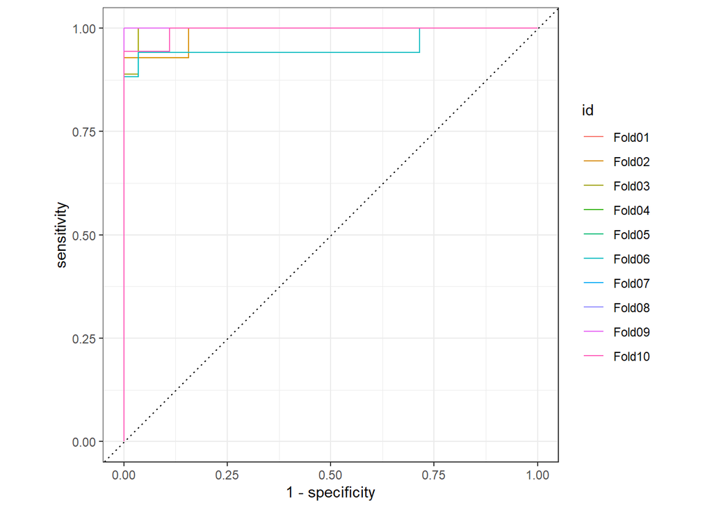

We tune the model’s $l_1$ penalty by creating a grid of 100 sensible values to try with `grid_regular()`.

*Figure 4*

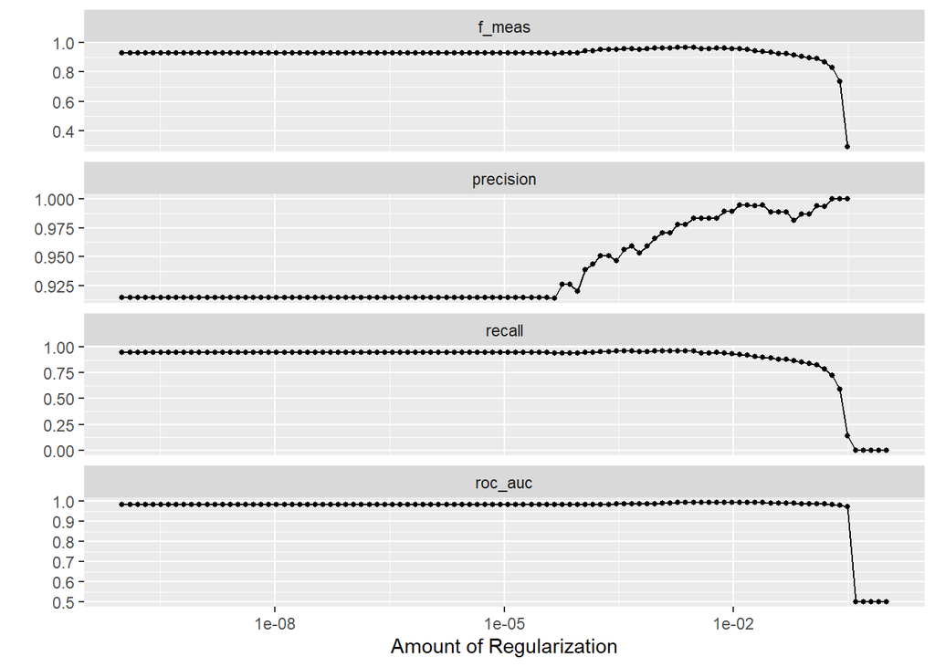

*Table 6*

| penalty | .metric | .estimator | mean | n | std_err | .config |
| --- | --- | --- | --- | --- | --- | --- |
| 0.0023645 | recall | binary | 0.9623716 | 10 | 0.0149687 | Preprocessor1_Model074 |
| 0.0002915 | recall | binary | 0.9599907 | 10 | 0.0186653 | Preprocessor1_Model065 |
| 0.0003678 | recall | binary | 0.9599907 | 10 | 0.0186653 | Preprocessor1_Model066 |
| 0.0004642 | recall | binary | 0.9599907 | 10 | 0.0186653 | Preprocessor1_Model067 |
| 0.0009326 | recall | binary | 0.9599907 | 10 | 0.0186653 | Preprocessor1_Model070 |

*Table 7*

| penalty | .config |
| --- | --- |
| 0.0023645 | Preprocessor1_Model074 |

We learn that the value of $l_1$ that yields the best recall (𝜇= 0.96) is 0.0023645, and that this value also yields high roc_auc.

*Table 8*

| term | estimate | penalty |
| --- | --- | --- |
| smoothness_se | -81.7360218 | 0.0023645 |
| smoothness_worst | -30.4309233 | 0.0023645 |
| concave.points_worst | -24.1484203 | 0.0023645 |
| concavity_mean | -9.4756487 | 0.0023645 |
| symmetry_worst | -9.0726962 | 0.0023645 |
| radius_se | -4.2431875 | 0.0023645 |
| concavity_worst | -1.6050420 | 0.0023645 |
| radius_worst | -0.7668461 | 0.0023645 |
| concave.points_mean | -0.3271499 | 0.0023645 |
| texture_worst | -0.2657175 | 0.0023645 |
| area_worst | -0.0021161 | 0.0023645 |
| texture_se | 0.4580905 | 0.0023645 |
| fractal_dimension_mean | 5.7519065 | 0.0023645 |
| (Intercept) | 32.6443195 | 0.0023645 |
| compactness_se | 37.6544901 | 0.0023645 |

*Table 9*

```r
# Evaluate on test data
lasso_final <- last_fit(final_lasso, split = training_split, metrics = metrics)
collect_metrics(lasso_final, summarize = TRUE)
```

| .metric | .estimator | .estimate | .config |
| --- | --- | --- | --- |
| f_meas | binary | 0.9655172 | Preprocessor1_Model1 |
| precision | binary | 0.9545455 | Preprocessor1_Model1 |
| recall | binary | 0.9767442 | Preprocessor1_Model1 |
| roc_auc | binary | 0.9938630 | Preprocessor1_Model1 |

```r
# collect_predictions(lasso_final)
```

*Figure 5*

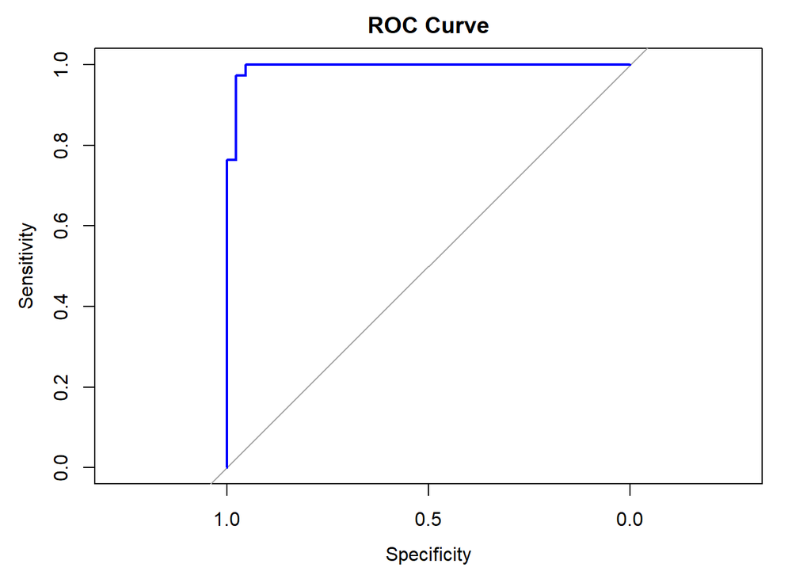

With a penalty parameter set at 0.0023645, the majority of coefficients were effectively regularized to zero, resulting in the selection of 14 features considered most important for the classification.  
Among these, the variable that contributes the most to classify the breast mass as malignanat is the compactness SE: the more changes or variations in the mass’ compactness, the more likely for it to be classified as malignant. To a lesser extent, mean fractal dimension also contributes to a malignant classification.  
On the other hand, higher values of smoothness, concavity and symmetry are associated with a more likely benign classification. These features seem to be characteristics observed in non-cancerous masses.

# Conclusion

Strikingly, both models yield almost the exact same performance, both being very effective in the binary classification task. It’s possible that both models converge to similar solutions during training and hyperparameter tuning. Overall, we managed to achieve a high level of recall with both models, which was our goal to minimize false negatives in cancer detection.

*Figure 6*

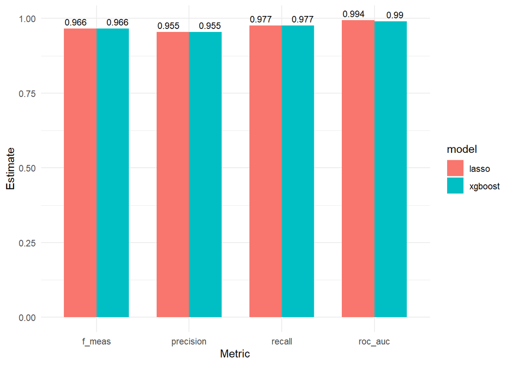

*Table 10*

| .metric | .estimator | .estimate | .config | model |
| --- | --- | --- | --- | --- |
| f_meas | binary | 0.9655172 | Preprocessor1_Model1 | xgboost |
| precision | binary | 0.9545455 | Preprocessor1_Model1 | xgboost |
| recall | binary | 0.9767442 | Preprocessor1_Model1 | xgboost |
| roc_auc | binary | 0.9903101 | Preprocessor1_Model1 | xgboost |
| f_meas | binary | 0.9655172 | Preprocessor1_Model1 | lasso |
| precision | binary | 0.9545455 | Preprocessor1_Model1 | lasso |
| recall | binary | 0.9767442 | Preprocessor1_Model1 | lasso |
| roc_auc | binary | 0.9938630 | Preprocessor1_Model1 | lasso |